# HCI/PSYCH 522

This page provides a summary of statistical methods in R used to analyze normal data. It begins by considering a single group and then expands to multiple groups. For completing course activities, you should copy relevant code from here and modifying it as necessary.

In the code below, we will make use of the `tidyverse` package, so make sure to load it at the beginning of your R session.

```r
library("tidyverse")
theme_set(theme_bw()) # set a figure theme
```

## Single group

Normal data, written $Y_i \stackrel{ind}{\sim} N(\mu,\sigma^2)$ for individuals $i=1,\ldots,n$ is characterized by a group of continuous observations with

- common mean $\mu$,
- common standard deviation $\sigma$,
- normal distribution (bell-shaped histogram), and
- each observation is independent.

If our sample is based on a random sample from our population, then we can make inferences about that entire population.

Suppose, we obtain 33 observations with a sample mean of 13 and a sample standard deviation of 2. In R, we can write

```r
n  <- 33
mn <- 13
s  <- 2
se <- s/sqrt(n) # standard error (used often below)
```

Our posterior belief about the unknown population mean $\mu$ is represented by the following curve

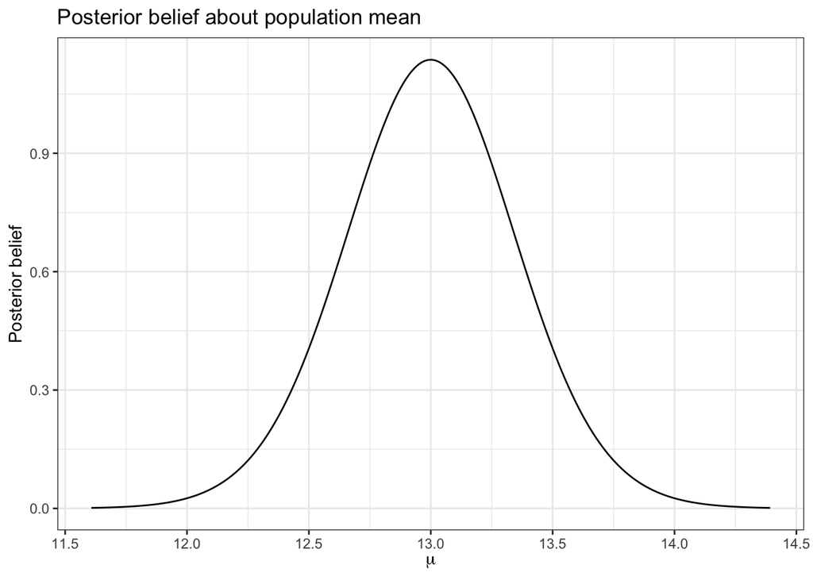

```r
# Probability density function for a location-scale t-distribution
dlst <- function(x, df, location, scale) {
  dt((x-location)/scale, df = df)/scale
}

d <- data.frame(mu = seq(from = mn - 4*se, to = mn + 4*se, length = 1001)) %>%
  mutate(density = dlst(mu, df = n-1, location = mn, scale = se))

ggplot(d, aes(x = mu, y = density)) +
  geom_line() +
  labs(x = expression(mu),
       y = "Posterior belief",
       title = "Posterior belief about population mean")
```

We can calculate probabilities based on this curve by finding the area under the curve. For example, to find the probability that $\mu$ is between 12 and 13.5 we use

```r
pt( (13.5-mn)/se, df = n-1) - pt( (12-mn)/se, df = n-1)
```

```
## [1] 0.9160785
```

which corresponds to the area

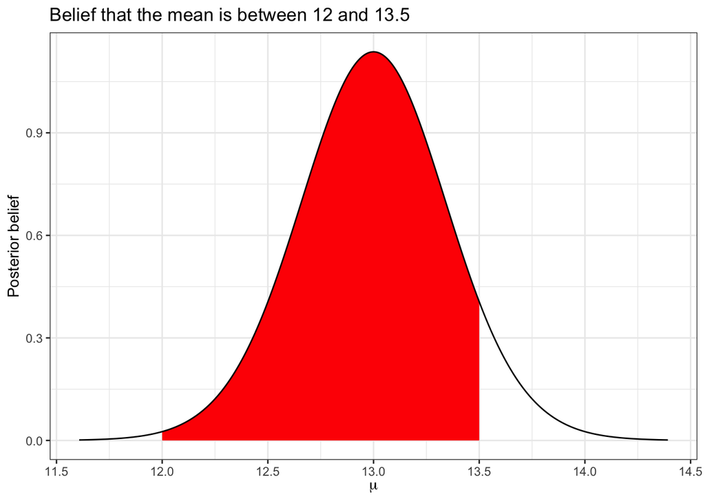

```r
ggplot(d, aes(x = mu, y = density)) +
  stat_function(fun = dlst, xlim = c(12,13.5), geom="area", fill = "red",
                args = list(df = n-1, location = mn, scale = se)) +
  geom_line() +
  labs(x = expression(mu),
       y = "Posterior belief",
       title = "Belief that the mean is between 12 and 13.5")
```

A 95% credible interval is calculated using

```r
a <- 1-0.95
qt(c(a/2, 1-a/2), df = n-1) * se + mn
```

```
## [1] 12.29083 13.70917
```

## Multiple groups

Normal data for multiple groups is written $Y_{i,g} \stackrel{ind}{\sim} N(\mu_g, \sigma_g^2)$ for $g=1,\ldots,G$ where $g$ is the number of groups and $i = 1,\ldots,n_g$ where $n_g$ is the number of individuals in group $g$. For group $g$, we have

- common mean $\mu_g$,
- common standard deviation $\sigma_g$,
- normal distribution (bell-shaped histogram), and
- each observation is independent.

And, we have independence of observations across the two groups.

If our sample is based on a random sample from our population, then we can make inferences about that entire population.

Rather than having summary data, we will instead record our data in a file and read it in to R.

```r
d <- read_csv("normal-data.csv")
head(d)
```

```
## # A tibble: 6 × 2
##   group      y
##   <chr>  <dbl>
## 1 group1    66
## 2 group1    65
## 3 group1    66
## 4 group1    67
## 5 group1    69
## 6 group1    67
```

We can calculate summary statistics from these data

```r
sm <- d %>%
  group_by(group) %>%
  summarize(n = n(),
            mn = mean(y),
            s = sd(y)) %>%
  mutate(se = s/sqrt(n))

sm
```

```
## # A tibble: 2 × 5
##   group      n    mn     s    se
##   <chr>  <int> <dbl> <dbl> <dbl>
## 1 group1    15  66.9  1.28 0.330
## 2 group2    20  65.9  2.31 0.518
```

We can plot our posterior beliefs using the following code

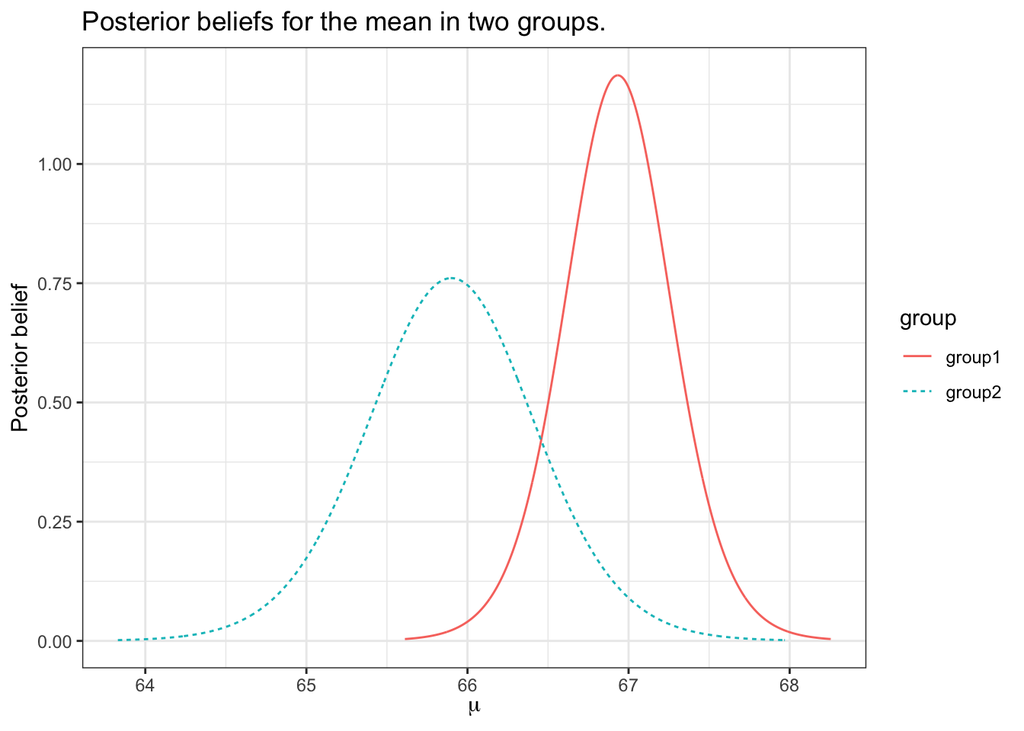

```r
# Function to create the posterior
create_posterior <- function(sm) {

  data.frame(mu = seq(sm$mn-4*sm$se, sm$mn+4*sm$se, length=1001)) %>%
    mutate(posterior = dlst(mu, df = sm$n-1, location = sm$mn, scale = sm$se))
}

# Construct the curves
curves <- sm %>%
  group_by(group) %>%
  do(create_posterior(.)) %>%
  mutate(group = factor(group)) # so that we can use it as a linetype

# Plot curves
ggplot(curves, aes(x = mu, y = posterior, color = group, linetype = group)) +
  geom_line() +
  labs(x = expression(mu),
       y = "Posterior belief",
       title = "Posterior beliefs for the mean in two groups.")
```

If we want to calculate beliefs that one groups mean is larger than the other, we use a Monte Carlo approach. This approach first simulates values for $\mu_1$ and $\mu_2$.

```r
n_reps <- 100000
mu1 <- rt(n_reps, df = sm$n[1]-1) * sm$se[1] + sm$mn[1]
mu2 <- rt(n_reps, df = sm$n[2]-1) * sm$se[2] + sm$mn[2]
```

Then we calculate the proportion of times that $\mu_1$ is larger than $\mu_2$ which is calculated in R using the `mean` function.

```r
mean(mu1 > mu2)
```

```
## [1] 0.9447
```

```r
a <- 1-0.95
quantile(mu1 - mu2, probs = c(a/2, 1-a/2))
```

```
##       2.5%      97.5%
## -0.2556401  2.3249371
```

For additional groups a similar process can be followed.